# Chapter 8 - Markov Chain Monte Carlo

```r
library(tidyverse)
library(brms)
library(tidybayes)
library(bayesplot)
library(rcartocolor)
devtools::load_all()
```

```
Loading rethinkingmooc
```

```r
colour_theme <- "BurgYl"
palette <- carto_pal(7, colour_theme)
```

# Notes

## Metropolis algorithms for full joint probability exploration

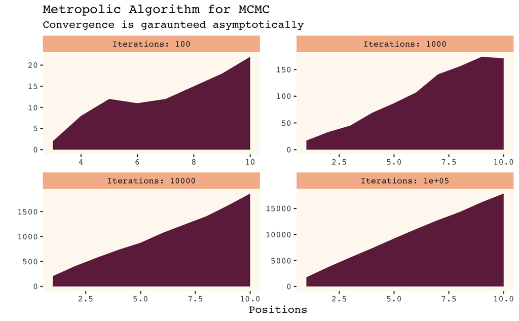

```r
king_markov <- function(num_weeks = 1e5, current = 10) {
  # The position vector records visits
  positions <- rep(0, num_weeks)
  for (i in 1:num_weeks) {
    positions[i] <- current
    # Consider moving to an adjacent direction
    proposal <- current + sample(c(-1, 1), size = 1)
    # Logic to make sure we loop around between 1 <-> 10
    if (proposal < 1) proposal <- 10
    if (proposal > 10) proposal <- 1
    # An island's population is proportional to it's index
    # Which means we'll hill climb for sure
    # And potentially descend by chance
    prob_move <- proposal / current
    current <- ifelse(runif(1) < prob_move, proposal, current)
  }
  positions
}

weeks <- c(1e2, 1e3, 1e4, 1e5)

data_frame(
  positions = flatten_dbl(purrr::map(weeks, king_markov)),
  lables = flatten_chr(purrr::map(weeks, ~ rep(paste(.x), .x)))) %>%
  mutate(lables = str_c("Iterations: ", lables)) %>%
    ggplot(aes(positions)) +
      geom_density(stat = "count", fill = palette[7], colour = "transparent") +
      facet_wrap(~ lables, scales="free", labeller = labeller(label_both)) +
      xlab("Positions") + ylab("") +
      ggtitle("Metropolic Algorithm for MCMC",
              "Convergence is garaunteed asymptotically") +
      theme_burgyl()
```

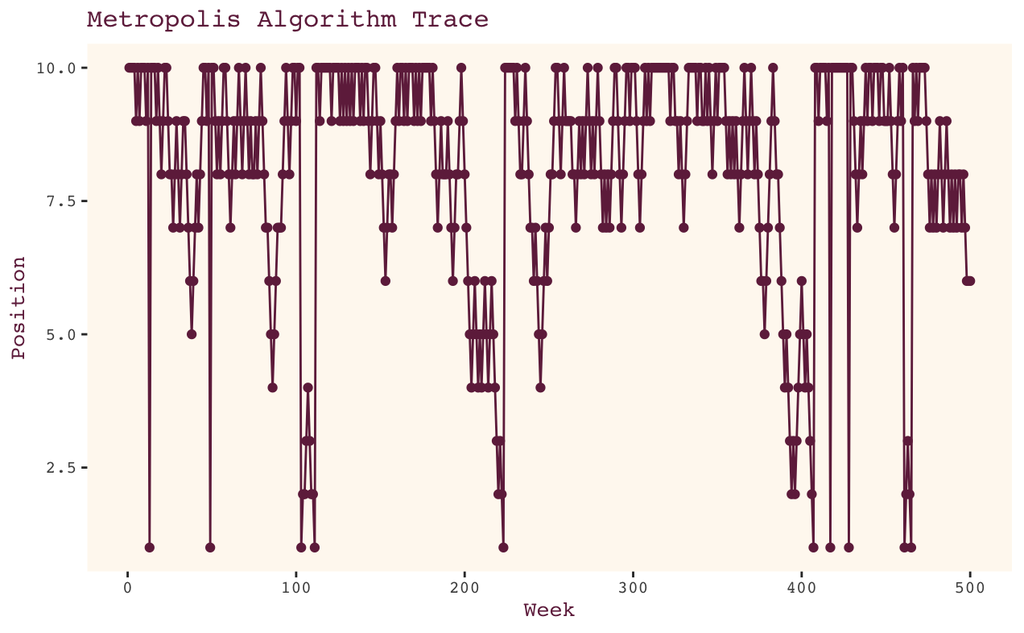

```r
data_frame(positions = king_markov(500),
           week = 1:length(positions)) %>%
  ggplot(aes(week, positions)) +
    geom_line(colour = palette[7]) +
    geom_point(colour = palette[7]) +
    xlab("Week") + ylab("Position") +
    theme(text = element_text(family = "Courier", size = 10,
                              colour = palette[7]),
      panel.background = element_rect(fill = alpha(palette[1], 1/4)),
      panel.grid = element_blank(),
      legend.position = c(1, 1),
      legend.justification = c(1, 1),
      legend.background = element_rect(fill = "transparent"),
      legend.title = element_blank()) +
    ggtitle("Metropolis Algorithm Trace")
```

The program above implements a special case of the general metrpolis algorithm for MCMC. Each island represents a parameter values, each population size is the posterior probability, and each week is a single sample from the joint posterior.

## Markov chain Monte Carlo

Gibbs sampling and Hamiltonian Monte Carlo are the two leading methods out there today.

Gibbs sampling that does a better job at making movement proposals by adjusting itself intelligently depending upon what its learned about the parameters so far. It computes adaptive proposals using particular combinations of prior distributions and likelihoods known as conjugate paris. Sometimes, conjugate riors can be silly, as picking a prior so that a model fits efficiently goes against scientific inquiry. It is also inefficient when the parameter space is very large.

HMC works by making its parameter suggestions more efficient. It climbs a gradient on each suggestion allowing for more effective posterior samples. This doesn’t work quite as well for discrete data. It also requires a ton of tuning parameters. Luckly, `Stan` can intelligently pick these for us.

## Easy HMC: brm

We’ll redo the ruggedness example again end to end here.

```r
library(rethinking)
data(rugged)
d <- rugged
detach(package:rethinking)
library(brms)
library(tidybayes)
rm(rugged)

d <- d %>%
  mutate(log_gdp = log(rgdppc_2000))

dd <- d %>%
  filter(complete.cases(rgdppc_2000))

dd.trim <-
  dd %>%
  select(log_gdp, rugged, cont_africa)

str(dd.trim)
```

```
'data.frame':   170 obs. of  3 variables:
 $ log_gdp    : num  7.49 8.22 9.93 9.41 7.79 ...
 $ rugged     : num  0.858 3.427 0.769 0.775 2.688 ...
 $ cont_africa: int  1 0 0 0 0 0 0 0 0 1 ...
```

Fit the log_gdp of a country as a function of ruggedness and its interaction with being in Africa.

```r
b8.1 <- brm(data = dd, family = gaussian,
      log_gdp ~ 1 + rugged + cont_africa + rugged:cont_africa,
      prior = c(prior(normal(0, 100), class = Intercept),
                prior(normal(0, 10), class = b),
                prior(cauchy(0, 2), class = sigma)),
      refresh = 0)
summary(b8.1)
```

```
 Family: gaussian
  Links: mu = identity; sigma = identity
Formula: log_gdp ~ 1 + rugged + cont_africa + rugged:cont_africa
   Data: dd (Number of observations: 170)
Samples: 4 chains, each with iter = 2000; warmup = 1000; thin = 1;
         total post-warmup samples = 4000

Population-Level Effects:
                   Estimate Est.Error l-95% CI u-95% CI Eff.Sample Rhat
Intercept              9.22      0.14     8.95     9.50       2752 1.00
rugged                -0.20      0.08    -0.36    -0.05       2681 1.00
cont_africa           -1.95      0.23    -2.41    -1.49       2359 1.00
rugged:cont_africa     0.40      0.13     0.14     0.66       2324 1.00

Family Specific Parameters:
      Estimate Est.Error l-95% CI u-95% CI Eff.Sample Rhat
sigma     0.95      0.05     0.85     1.07       3606 1.00

Samples were drawn using sampling(NUTS). For each parameter, Eff.Sample
is a crude measure of effective sample size, and Rhat is the potential
scale reduction factor on split chains (at convergence, Rhat = 1).
```

```r
post <- posterior_samples(b8.1)

post %>%
  gather(Parameter, Samples) %>%
  group_by(Parameter) %>%
  mode_hdi(Samples, .width = c(.95))
```

| Parameter | Samples | .lower | .upper | .width | .point | .interval |
| --- | --- | --- | --- | --- | --- | --- |
| b_cont_africa | -1.9161891 | -2.3802613 | -1.47324542 | 0.95 | mode | hdi |
| b_Intercept | 9.2136432 | 8.9448843 | 9.49484759 | 0.95 | mode | hdi |
| b_rugged | -0.2212503 | -0.3574213 | -0.05142309 | 0.95 | mode | hdi |
| b_rugged:cont_africa | 0.4138613 | 0.1352818 | 0.65118334 | 0.95 | mode | hdi |
| lp__ | -247.5278900 | -251.6875609 | -246.10556999 | 0.95 | mode | hdi |
| sigma | 0.9303497 | 0.8401455 | 1.05539245 | 0.95 | mode | hdi |

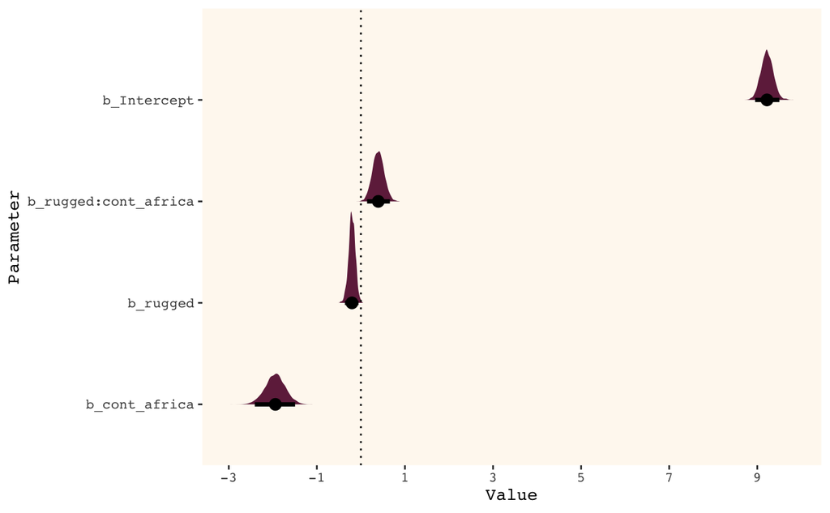

```r
post %>%
  select(starts_with("b_")) %>%
  gather(Variable, Value) %>%
  ggplot(aes(y = fct_reorder(Variable, Value, mean), x = Value)) +
    geom_halfeyeh(.width = c(.95), fill = palette[7], colour = "transparent") +
    geom_vline(xintercept = 0, linetype = 3) +
    theme_burgyl() + ylab("Parameter") +
    scale_x_continuous(breaks = seq(from=-5, to=10, by = 2))
```

```r
loo(b8.1)
```

```
Computed from 4000 by 170 log-likelihood matrix
```

|  | Estimate | SE |
| --- | --- | --- |
| elpd_loo | -234.7 | 7.4 |
| p_loo | 5.1 | 0.9 |
| looic | 469.4 | 14.9 |

```
------
Monte Carlo SE of elpd_loo is 0.0.

All Pareto k estimates are good (k < 0.5).
See help('pareto-k-diagnostic') for details.
```

```r
waic(b8.1)
```

```
Computed from 4000 by 170 log-likelihood matrix
```

|  | Estimate | SE |
| --- | --- | --- |
| elpd_waic | -234.6 | 7.4 |
| p_waic | 5.1 | 0.9 |
| waic | 469.3 | 14.8 |

```
2 (1.2%) p_waic estimates greater than 0.4. We recommend trying loo instead.
```

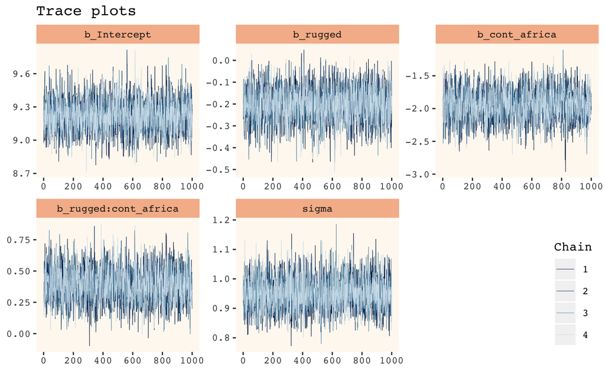

```r
post <- posterior_samples(b8.1, add_chain = T)

mcmc_trace(post[, c(1:5, 7)],
           facet_args = list(ncol = 3),
           size = .15) +
  labs(title = "Trace plots") +
  theme_burgyl(legend_location = "br")
```

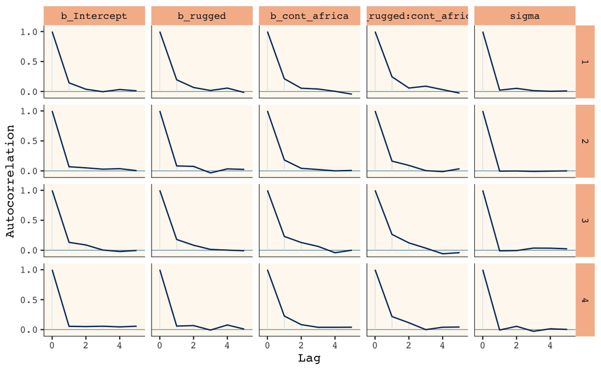

```r
mcmc_acf(post,
         pars = c("b_Intercept", "b_rugged",
                  "b_cont_africa", "b_rugged:cont_africa",
                  "sigma"), lags = 5) +
  theme_burgyl()
```

## Care and feeding of your Markov Chains

Below, we regress on a constant to find the mean of a vector. We provide improper flat priors that force Stan in to an unrealistic search space. The result are unrealistic estimates.

```r
b8.2 <-
  brm(data = list(y = c(-1, 1)),
      family = gaussian,
      y ~ 1,
      prior = c(prior(uniform(-1e10, 1e10), class = Intercept),
                prior(uniform(0, 1e10), class = sigma)),
      inits = list(list(Intercept = 0, sigma = 1),
                   list(Intercept = 0, sigma = 1)),
      iter = 4000, warmup = 1000, chains = 2)
```

```
There were 166 divergent transitions after warmup. Increasing adapt_delta above 0.8 may help. See
http://mc-stan.org/misc/warnings.html#divergent-transitions-after-warmupThere were 690 transitions after warmup that exceeded the maximum treedepth. Increase max_treedepth above 10. See
http://mc-stan.org/misc/warnings.html#maximum-treedepth-exceededThere were 2 chains where the estimated Bayesian Fraction of Missing Information was low. See
http://mc-stan.org/misc/warnings.html#bfmi-lowExamine the pairs() plot to diagnose sampling problems
```

```r
summary(b8.2)
```

```
There were 166 divergent transitions after warmup. Increasing adapt_delta above 0.8 may help.
See http://mc-stan.org/misc/warnings.html#divergent-transitions-after-warmup
```

```
 Family: gaussian
  Links: mu = identity; sigma = identity
Formula: y ~ 1
   Data: list(y = c(-1, 1)) (Number of observations: 2)
Samples: 2 chains, each with iter = 4000; warmup = 1000; thin = 1;
         total post-warmup samples = 6000

Population-Level Effects:
              Estimate    Est.Error      l-95% CI     u-95% CI Eff.Sample Rhat
Intercept -19026207.47 147283527.25 -371077174.82 148730119.13         98 1.01

Family Specific Parameters:
          Estimate    Est.Error l-95% CI      u-95% CI Eff.Sample Rhat
sigma 143795156.21 587189855.88   493.58 1485897882.80         59 1.04

Samples were drawn using sampling(NUTS). For each parameter, Eff.Sample
is a crude measure of effective sample size, and Rhat is the potential
scale reduction factor on split chains (at convergence, Rhat = 1).
```

Its obvious that these chains have not converged.

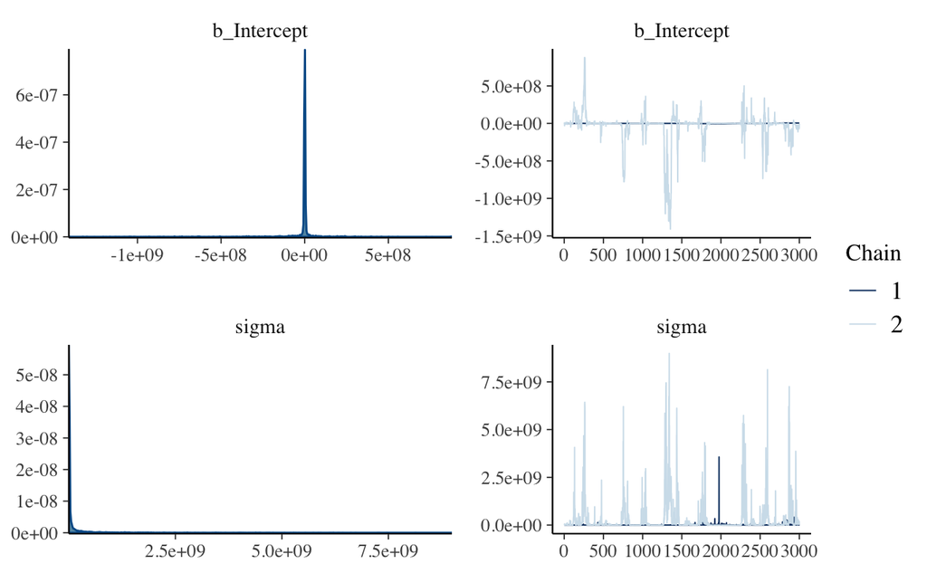

```r
plot(b8.2)
```

Lets try again with reasonable priors

```r
b8.3 <-
  brm(data = list(y = c(-1, 1)),
      family = gaussian,
      y ~ 1,
      prior = c(prior(normal(0, 10), class = Intercept),
                prior(cauchy(0, 1), class = sigma)),
      inits = list(list(Intercept = 0, sigma = 1),
                   list(Intercept = 0, sigma = 1)),
      iter = 4000, warmup = 1000, chains = 2)
```

```
There were 2 divergent transitions after warmup. Increasing adapt_delta above 0.8 may help. See
http://mc-stan.org/misc/warnings.html#divergent-transitions-after-warmupExamine the pairs() plot to diagnose sampling problems
```

```r
summary(b8.3)
```

```
There were 2 divergent transitions after warmup. Increasing adapt_delta above 0.8 may help.
See http://mc-stan.org/misc/warnings.html#divergent-transitions-after-warmup
```

```
 Family: gaussian
  Links: mu = identity; sigma = identity
Formula: y ~ 1
   Data: list(y = c(-1, 1)) (Number of observations: 2)
Samples: 2 chains, each with iter = 4000; warmup = 1000; thin = 1;
         total post-warmup samples = 6000

Population-Level Effects:
          Estimate Est.Error l-95% CI u-95% CI Eff.Sample Rhat
Intercept    -0.02      1.64    -3.44     3.22       1191 1.00

Family Specific Parameters:
      Estimate Est.Error l-95% CI u-95% CI Eff.Sample Rhat
sigma     2.11      2.56     0.60     7.13       1449 1.00

Samples were drawn using sampling(NUTS). For each parameter, Eff.Sample
is a crude measure of effective sample size, and Rhat is the potential
scale reduction factor on split chains (at convergence, Rhat = 1).
```

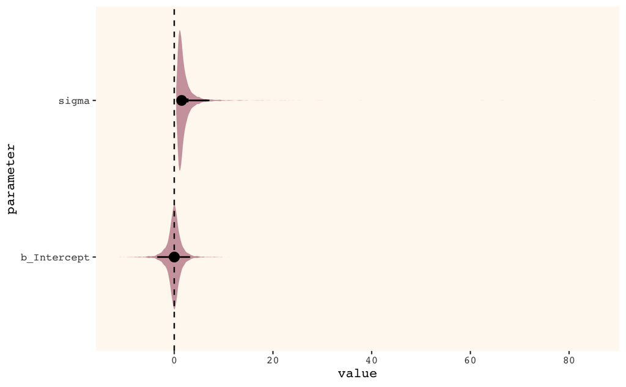

```r
posterior_samples(b8.3) %>%
  select(-lp__) %>%
  gather(parameter) %>%
  ggplot(aes(x = parameter, y = value)) +
    geom_eye(fill = alpha(palette[6], I(1/2))) +
    geom_hline(yintercept = 0, linetype = 2) +
    coord_flip() + theme_burgyl()
```

More information on what to set for your priors can be found here: https://github.com/stan-dev/stan/wiki/Prior-Choice-Recommendations